# PART 1 QUESTION BASED

# 4. Question:

Accuracy in understanding orders for a speech based bot at a restaurant is important for the Company X which has designed, marketed and launched the product for a contactless delivery due to the COVID-19 pandemic. Recognition accuracy that measures the percentage of orders that are taken correctly is 86.8%. Suppose that you place order with the bot and two friends of yours independently place orders with the same bot. Answer the following questions. A. What is the probability that all three orders will be recognised correctly? B. What is the probability that none of the three orders will be recognised correctly? C. What is the probability that at least two of the three orders will be recognised correctly?

```python
#solution: the given problem follows binomial distribution
k   =  np.arange(0,4)
p   =  0.868
n   =  3
binomial = stats.binom.pmf(k,n,p)
binomial
```

```
array([0.00229997, 0.0453721 , 0.2983559 , 0.65397203])
```

```python
# 4.A probability that all three orders will be recognised correctly = P1
P1 =round(binomial[3],4)
print(f'''probability that all three orders will be recognised correctly is {P1}''')
```

```
probability that all three orders will be recognised correctly is 0.654
```

```python
# 4.B  probability that none of the three orders will be recognised correctly =P2
P2 = round(binomial[0],4)
print(f''' probability that none of the three orders will be recognised correctly is {P2}''')
```

```
 probability that none of the three orders will be recognised correctly is 0.0023
```

```python
# 4.C  probability that at least two of the three orders will be recognised correctly =P3
binom_cum = stats.binom.cdf(k,n,p)
P3 = 1-round(binom_cum[1],4)
print( f'''probability that at least two of the three orders will be recognised correctly is {P3}''')
```

```
probability that at least two of the three orders will be recognised correctly is 0.9523
```

Answers: 4.A. probability that all three orders will be recognised correctly is 0.654 4.B. probability that none of the three orders will be recognised correctly is 0.0023 4.C. probability that at least two of the three orders will be recognised correctly is 0.9523

# 5. Question:

A group of 300 professionals sat for a competitive exam. The results show the information of marks obtained by them have a mean of 60 and a standard deviation of 12. The pattern of marks follows a normal distribution. Answer the following questions. A. What is the percentage of students who score more than 80. B. What is the percentage of students who score less than 50. C. What should be the distinction mark if the highest 10% of students are to be awarded distinction?

```python
# 5.A percentage of students who score more than 80
n= 300
mu = 60
sd = 12
```

```python
# 5.A percentage of students who score more than 80
x1 = 80
z = (x1-mu)/sd
P = 1 - stats.norm.cdf(z)
print(f'''percentage of students who score more than 80 is {round(P,4)*100} %''')
```

```
percentage of students who score more than 80 is 4.78 %
```

```python
# 5.B.percentage of students who score less than 50
x2 = 50
z1 = (x2-mu)/sd
z1
P1 = stats.norm.cdf(z1)
print(f'''percentage of students who score less than 50 is {round(P1,4)*100} %''')
```

```
percentage of students who score less than 50 is 20.23 %
```

# 5.C. Distinction mark if the highest 10% of students are to be awarded distinction the top 10% of the students, corresponds to (100-10)% it is 90 marks. The Z score corresponds to 90(to the upper tail side from the mean) from standard normal distribution table is 1.282 P[Z>=(x3-mu)/sd] =0.1 (x3 - mu)/sd = 1.282 x3 = 75.384 distinction marks is 75Answers: 5.A. percentage of students who score more than 80 is 4.78 % 5.B. percentage of students who score less than 50 is 20.23 % 5.C. distinction marks is 75

# 6. Question:

Explain 1 real life industry scenario other than the ones mentioned above where you can use the concepts learnt in this module of Applied statistics to get a data driven business solution.

In this dataset example we will discuss the main methods in action by analyzing a dataset on the churn rate of telecom operator clients. The objective of the study is to predict that a customer is not loyal (Churn=1) in the case when the number of calls to the service center is greater than 3 and the International Plan is added (and predicting Churn=0 otherwise) 1. The first step is data reading and exploration. Using python libraries of Numpy,Pandas the dataset can be cleaned and visualized and later hypothetical can be made on the dataset to analyze the dataset. Pandas is a Python library that provides extensive means for data analysis. Data scientists often work with data stored in table formats like .csv, .tsv, or .xlsx. Pandas makes it very convenient to load, process, and analyze such tabular data using SQL-like queries. In conjunction with Matplotlib and Seaborn, Pandas provides a wide range of opportunities for visual analysis of tabular data.The main data structures in Pandas are implemented with Series and DataFrame classes. The former is a one-dimensional indexed array of some fixed data type. The latter is a two-dimensional data structure - a table - where each column contains data of the same type. You can see it as a dictionary of Series instances. DataFrames are great for representing real data: rows correspond to instances (examples, observations, etc.), and columns correspond to features of these instances. 2. Reading CSV file 3. Detecting the size and shape of the dataset using .columns,.shape,.info commands. 4. Analysing datatype of the attributes. 5. To do statistics with the exploration of describe command. 6. Indexing and retrieving data 7.Determining What are average values of numerical features for churned users? 8. Determining How much time (on average) do churned users spend on the phone during daytime? 9. Determining What is the maximum length of international calls among loyal users (Churn == 0) who do not have an international plan? 10.Grouping, using contingency table to see how the observations in our sample are distributed in the context of two variables. 11.First attempt at predicting telecom churn is related to the International plan feature using a crosstab contingency table and also through visual analysis to be made by using matplotlib and seaborn. 12. After doing detailed analysis without using machinelearning models these conclusion can be drawn: i) Predicting that a customer is not loyal (Churn=1) in the case when the number of calls to the service center is greater than 3 and the International Plan is added (and predicting Churn=0 otherwise), we might expect an accuracy of 85.8% (we are mistaken only 464 + 9 times). This number, 85.8%, that we got through this very simple reasoning serves as a good starting point (baseline) for the further machine learning models that we will build. ii) The share of loyal clients in the sample is 85.5%. The most naive model that always predicts a "loyal customer" on such data will guess right in about 85.5% of all cases. That is, the proportion of correct answers (accuracy) of subsequent models should be no less than this number, and will hopefully be significantly higher; With the help of a simple forecast that can be expressed by the following formula: "International plan = True & Customer Service calls > 3 => Churn = 1, else Churn = 0", we can expect a guessing rate of 85.8%, which is just above 85.5%.

# PART TWO Project Based

```python
#importing libraries
import numpy as np
import pandas as pd
import matplotlib.pyplot as plt
import seaborn as sns
%matplotlib inline
```

reading csv file

```python
bb = pd.read_csv('DS - Part2 - Basketball.csv')    # reading CSV file
bb.head()
```

|  | Team | Tournament | Score | PlayedGames | WonGames | DrawnGames | LostGames | BasketScored | BasketGiven | TournamentChampion | Runner-up | TeamLaunch | HighestPositionHeld |
| --- | --- | --- | --- | --- | --- | --- | --- | --- | --- | --- | --- | --- | --- |
| 0 | Team 1 | 86 | 4385 | 2762 | 1647 | 552 | 563 | 5947 | 3140 | 33 | 23 | 1929 | 1 |
| 1 | Team 2 | 86 | 4262 | 2762 | 1581 | 573 | 608 | 5900 | 3114 | 25 | 25 | 1929 | 1 |
| 2 | Team 3 | 80 | 3442 | 2614 | 1241 | 598 | 775 | 4534 | 3309 | 10 | 8 | 1929 | 1 |
| 3 | Team 4 | 82 | 3386 | 2664 | 1187 | 616 | 861 | 4398 | 3469 | 6 | 6 | 1931to32 | 1 |
| 4 | Team 5 | 86 | 3368 | 2762 | 1209 | 633 | 920 | 4631 | 3700 | 8 | 7 | 1929 | 1 |

```python
# getting information of the attributes data types
bb.info()
```

```
<class 'pandas.core.frame.DataFrame'>
RangeIndex: 61 entries, 0 to 60
Data columns (total 13 columns):
 #   Column               Non-Null Count  Dtype
---  ------               --------------  -----
 0   Team                 61 non-null     object
 1   Tournament           61 non-null     int64
 2   Score                61 non-null     object
 3   PlayedGames          61 non-null     object
 4   WonGames             61 non-null     object
 5   DrawnGames           61 non-null     object
 6   LostGames            61 non-null     object
 7   BasketScored         61 non-null     object
 8   BasketGiven          61 non-null     object
 9   TournamentChampion   61 non-null     object
 10  Runner-up            61 non-null     object
 11  TeamLaunch           61 non-null     object
 12  HighestPositionHeld  61 non-null     int64
dtypes: int64(2), object(11)
memory usage: 6.3+ KB
```

Observation: Only the variables 'Tournament' and 'HighestPositionHeld' are belong to the integer data type. Need to convert the object type to numeric to do statisical analysis for continious variables.

```python
# checking the dimension
bb.shape
```

```
(61, 13)
```

```python
##Identifying the null values in the data frame
bb.isnull().sum()
```

```
Team                   0
Tournament             0
Score                  0
PlayedGames            0
WonGames               0
DrawnGames             0
LostGames              0
BasketScored           0
BasketGiven            0
TournamentChampion     0
Runner-up              0
TeamLaunch             0
HighestPositionHeld    0
dtype: int64
```

```python
##Identifying duplicates records in the data frame
dupes = bb.duplicated()
sum(dupes)
```

```
0
```

```python
#checking for the null values in the dataset
bb.isnull().values.any()
```

```
False
```

Observation: Found None.

```python
bb.isnull().sum()
```

```
Team                   0
Tournament             0
Score                  0
PlayedGames            0
WonGames               0
DrawnGames             0
LostGames              0
BasketScored           0
BasketGiven            0
TournamentChampion     0
Runner-up              0
TeamLaunch             0
HighestPositionHeld    0
dtype: int64
```

```python
# Cleaning the attribute 'TeamLaunch' as it found irregular entries
bb['TeamLaunch']= bb['TeamLaunch'].map(str)   #converting in to string type
my_list=[]
for i in bb['TeamLaunch']:
    my_list.append(i[:4])                     #considering first 4 elements
bb['TeamLaunch'] =my_list
bb.head()
```

|  | Team | Tournament | Score | PlayedGames | WonGames | DrawnGames | LostGames | BasketScored | BasketGiven | TournamentChampion | Runner-up | TeamLaunch | HighestPositionHeld |
| --- | --- | --- | --- | --- | --- | --- | --- | --- | --- | --- | --- | --- | --- |
| 0 | Team 1 | 86 | 4385 | 2762 | 1647 | 552 | 563 | 5947 | 3140 | 33 | 23 | 1929 | 1 |
| 1 | Team 2 | 86 | 4262 | 2762 | 1581 | 573 | 608 | 5900 | 3114 | 25 | 25 | 1929 | 1 |
| 2 | Team 3 | 80 | 3442 | 2614 | 1241 | 598 | 775 | 4534 | 3309 | 10 | 8 | 1929 | 1 |
| 3 | Team 4 | 82 | 3386 | 2664 | 1187 | 616 | 861 | 4398 | 3469 | 6 | 6 | 1931 | 1 |
| 4 | Team 5 | 86 | 3368 | 2762 | 1209 | 633 | 920 | 4631 | 3700 | 8 | 7 | 1929 | 1 |

```python
# most of the values in the last row are empty hence deleting
bb =bb.drop(index=60)
bb.head()
```

|  | Team | Tournament | Score | PlayedGames | WonGames | DrawnGames | LostGames | BasketScored | BasketGiven | TournamentChampion | Runner-up | TeamLaunch | HighestPositionHeld |
| --- | --- | --- | --- | --- | --- | --- | --- | --- | --- | --- | --- | --- | --- |
| 0 | Team 1 | 86 | 4385 | 2762 | 1647 | 552 | 563 | 5947 | 3140 | 33 | 23 | 1929 | 1 |
| 1 | Team 2 | 86 | 4262 | 2762 | 1581 | 573 | 608 | 5900 | 3114 | 25 | 25 | 1929 | 1 |
| 2 | Team 3 | 80 | 3442 | 2614 | 1241 | 598 | 775 | 4534 | 3309 | 10 | 8 | 1929 | 1 |
| 3 | Team 4 | 82 | 3386 | 2664 | 1187 | 616 | 861 | 4398 | 3469 | 6 | 6 | 1931 | 1 |
| 4 | Team 5 | 86 | 3368 | 2762 | 1209 | 633 | 920 | 4631 | 3700 | 8 | 7 | 1929 | 1 |

# Discover outliers with visualization tools

Box plot-

```python
# converting 'Score' attribute to int type
bb['Score'] = bb['Score'].astype(int)
bb['Score']
```

```
0     4385
1     4262
2     3442
3     3386
4     3368
5     2819
6     2792
7     2573
8     2109
9     1884
10    1814
11    1789
12    1471
13    1416
14    1389
```

[output cut: 46 more lines]

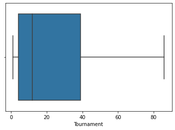

```python
sns.boxplot(x=bb['Tournament']);   # box plot
```

observation: All values are well within the quartiles.

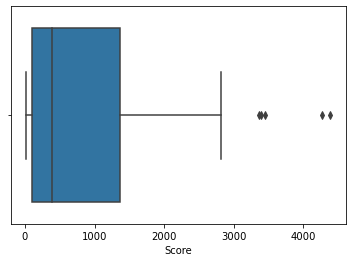

```python
sns.boxplot(x=bb['Score']);   # box plot
```

```python
# converting attributes to numeric type
cols = ['PlayedGames', 'WonGames', 'DrawnGames','LostGames','BasketScored','BasketGiven','TournamentChampion','Runner-up','TeamLaunch']
bb[cols] = bb[cols].apply(pd.to_numeric, errors='coerce', axis=1)
```

```python
bb.info()
```

```
<class 'pandas.core.frame.DataFrame'>
Int64Index: 60 entries, 0 to 59
Data columns (total 13 columns):
 #   Column               Non-Null Count  Dtype
---  ------               --------------  -----
 0   Team                 60 non-null     object
 1   Tournament           60 non-null     int64
 2   Score                60 non-null     int32
 3   PlayedGames          60 non-null     float64
 4   WonGames             60 non-null     float64
 5   DrawnGames           60 non-null     float64
 6   LostGames            60 non-null     float64
 7   BasketScored         60 non-null     float64
 8   BasketGiven          60 non-null     float64
 9   TournamentChampion   9 non-null      float64
 10  Runner-up            13 non-null     float64
 11  TeamLaunch           60 non-null     float64
 12  HighestPositionHeld  60 non-null     int64
dtypes: float64(9), int32(1), int64(2), object(1)
memory usage: 6.3+ KB
```

Observation: except 'Team' all other attributes are converted in to numeric

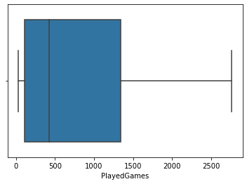

```python
sns.boxplot(x=bb['PlayedGames']);   # box plot
```

observation: All values are well within the quartiles.

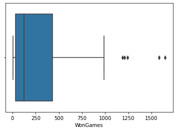

```python
sns.boxplot(x=bb['WonGames']);   # box plot
```

observation: Outliers are present above the quartile. i.e. some of the teams won games exceptionally well.

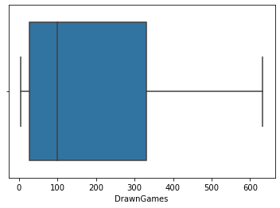

```python
sns.boxplot(x=bb['DrawnGames']);
```

observation: All values are well within the quartiles.

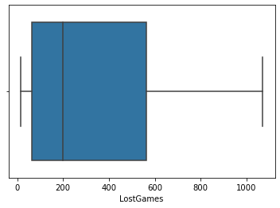

```python
sns.boxplot(x=bb['LostGames']);
```

observation: All values are well within the quartiles.

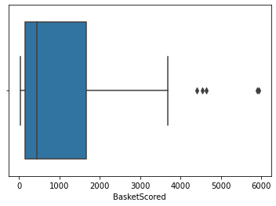

```python
sns.boxplot(x=bb['BasketScored']);
```

observation: Outliers are present above the quartile. i.e. some of the teams have basketscored exceptionally well.

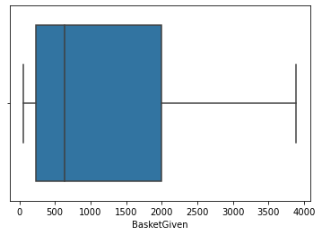

```python
sns.boxplot(x=bb['BasketGiven']);
```

observation: All values are well within the quartiles

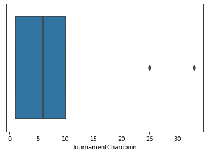

```python
sns.boxplot(x=bb['TournamentChampion']);
```

Observation: only few teams have won tournament championship.In that some teams have quite a few times. i.e. above 25 times

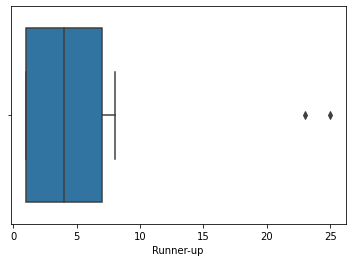

```python
sns.boxplot(x=bb['Runner-up']);
```

Observation: only few teams have won reached finals and lost there.that too around 25 times.

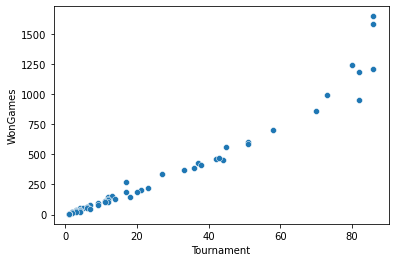

```python
sns.scatterplot(x=bb['Tournament'],y=bb['WonGames']);
```

Note: Looking at the plot above, we can see most of data points are lying on the bottom left side but there are points which are far from the population like top right corner. Those are potential outliers. i.e. few teams played good number of tournament and won good number of matches.

# Working with Outliers(Discover outliers with statistical rules):

Z-Score-

```python
from scipy import stats
import numpy as np
z = np.abs(stats.zscore(bb[bb.columns.difference(['Team'])]))   # get the z-score of every value with respect to their columns
print(z)
```

[output not shown]

[output cut: 125 more lines]

[output not shown]

Note: Looking the code and the output above, it is difficult to say which data point is an outlier. Let’s try and define a threshold to identify an outlier.

```python
threshold = 3
np.where(z > threshold)
```

```
(array([0, 0, 0, 1, 1], dtype=int64), array([ 1,  7, 11,  1, 11], dtype=int64))
```

```python
Q1 = bb.quantile(0.25)
Q3 = bb.quantile(0.75)
IQR = Q3 - Q1
print(IQR)
```

```
Tournament               35.00
Score                  1256.25
PlayedGames            1230.00
WonGames                398.00
DrawnGames              305.25
LostGames               500.75
BasketScored           1515.25
BasketGiven            1765.25
TournamentChampion        9.00
Runner-up                 6.00
TeamLaunch               42.50
HighestPositionHeld       7.00
dtype: float64
```

```python
np.where((bb < (Q1 - 1.5 * IQR)) | (bb > (Q3 + 1.5 * IQR)))
```

```
(array([0, 0, 0, 0, 0, 1, 1, 1, 1, 1, 2, 2, 2, 3, 3, 3, 4, 4, 4],
       dtype=int64),
 array([ 1,  6,  7, 11, 12,  1,  6,  7, 11, 12,  1,  7, 12,  1,  7, 12,  1,
         7, 12], dtype=int64))
```

# Data Visualisation

```python
# Counting the number of teams launched during particular year
my_tab = pd.crosstab(index=bb["TeamLaunch"],  # Make a crosstab
                     columns="count")                  # Name the count column
my_tab.head()
```

| col_0 TeamLaunch | count |
| --- | --- |
| 1929.0 | 10 |
| 1930.0 | 1 |
| 1931.0 | 1 |
| 1932.0 | 1 |
| 1933.0 | 1 |

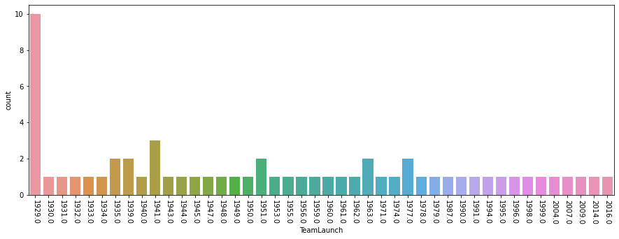

```python
fig = plt.figure(figsize = (15,5))
sns.countplot(x='TeamLaunch', data=bb)
plt.xticks(rotation=-90)
plt.show()
```

From the table it is found that the first team is launched during the year 1929. And also found that 10 teams were launched during that year. Latest team was launched in the year 2016.

```python
# Creating new dataframe for better analysis.
bb1 = bb[['Team','TeamLaunch','PlayedGames','BasketScored','WonGames','TournamentChampion']]
bb1.head()
```

|  | Team | TeamLaunch | PlayedGames | BasketScored | WonGames | TournamentChampion |
| --- | --- | --- | --- | --- | --- | --- |
| 0 | Team 1 | 1929.0 | 2762.0 | 5947.0 | 1647.0 | 33.0 |
| 1 | Team 2 | 1929.0 | 2762.0 | 5900.0 | 1581.0 | 25.0 |
| 2 | Team 3 | 1929.0 | 2614.0 | 4534.0 | 1241.0 | 10.0 |
| 3 | Team 4 | 1931.0 | 2664.0 | 4398.0 | 1187.0 | 6.0 |
| 4 | Team 5 | 1929.0 | 2762.0 | 4631.0 | 1209.0 | 8.0 |

```python
bb1.info()
```

```
<class 'pandas.core.frame.DataFrame'>
Int64Index: 60 entries, 0 to 59
Data columns (total 6 columns):
 #   Column              Non-Null Count  Dtype
---  ------              --------------  -----
 0   Team                60 non-null     object
 1   TeamLaunch          60 non-null     float64
 2   PlayedGames         60 non-null     float64
 3   BasketScored        60 non-null     float64
 4   WonGames            60 non-null     float64
 5   TournamentChampion  9 non-null      float64
dtypes: float64(5), object(1)
memory usage: 5.8+ KB
```

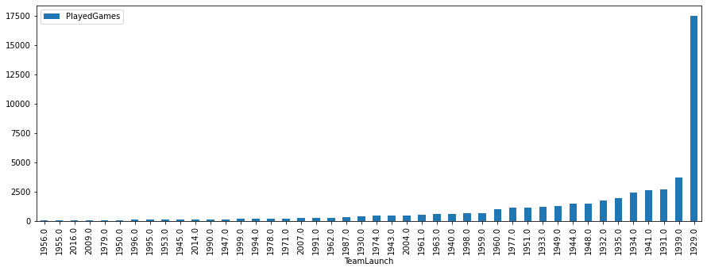

```python
# plot showing Team launched v/s number of games played
bb.groupby(by=['TeamLaunch'])['PlayedGames'].sum().reset_index().sort_values(['PlayedGames']).plot(x='TeamLaunch',y='PlayedGames',figsize=(15,5),kind='bar');
```

It is obvious from the above plot that the teams launched during the year 1929 has played most number of matches.

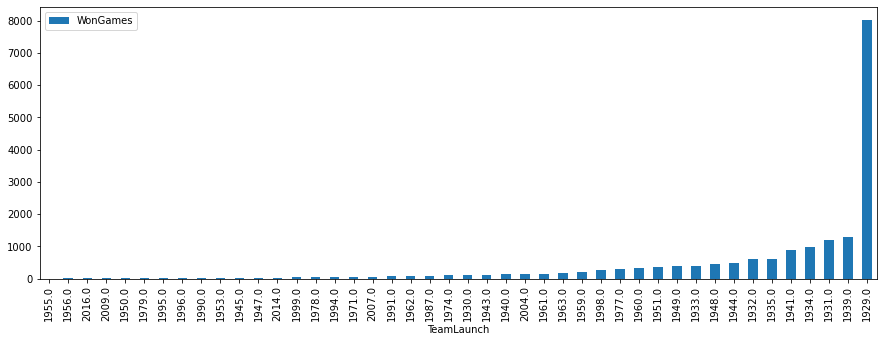

```python
# plot showing Team launched v/s number of games won
bb.groupby(by=['TeamLaunch'])['WonGames'].sum().reset_index().sort_values(['WonGames']).plot(x='TeamLaunch',y='WonGames',kind='bar',figsize=(15,5));
```

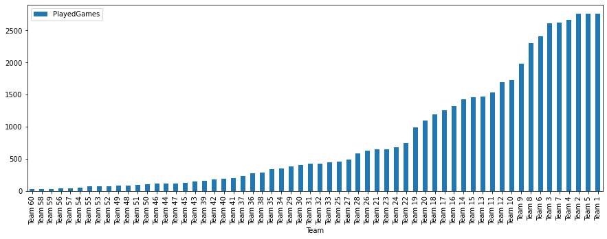

```python
#plot sowing which team has played more number of games
bb.groupby(by=['Team'])['PlayedGames'].sum().reset_index().sort_values(['PlayedGames']).plot(x='Team',y='PlayedGames',kind='bar',figsize=(15,5));
```

From the plot it is shown that Team 1, Team2 and Team 5 has played equal number of games.

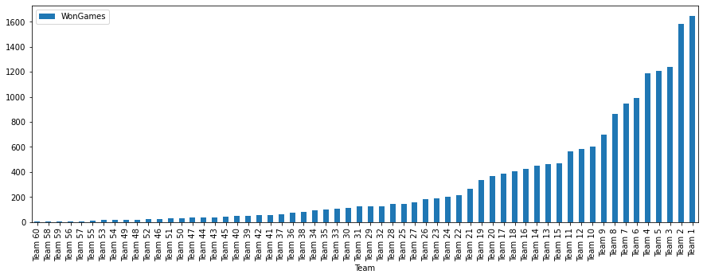

```python
#plot showing which team has won more number of games
bb.groupby(by=['Team'])['WonGames'].sum().reset_index().sort_values(['WonGames']).plot(x='Team',y='WonGames',kind='bar',figsize=(15,5));
```

inference from the plot is Team 1 has won more number of games follwed by Team 2, Team 3,Team 5 and Team 4.

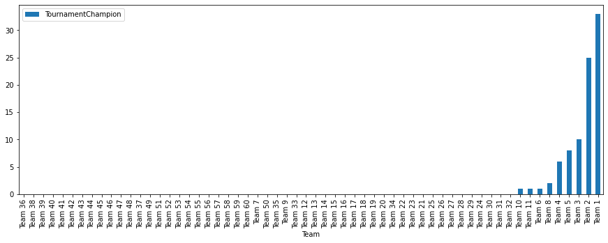

```python
#plot showing which team has held tounament championship most number of times
bb.groupby(by=['Team'])['TournamentChampion'].sum().reset_index().sort_values(['TournamentChampion']).plot(x='Team',y='TournamentChampion',kind='bar',figsize=(15,5));
```

from the plot it is infered that Team 1 has got more Tournament Champion.

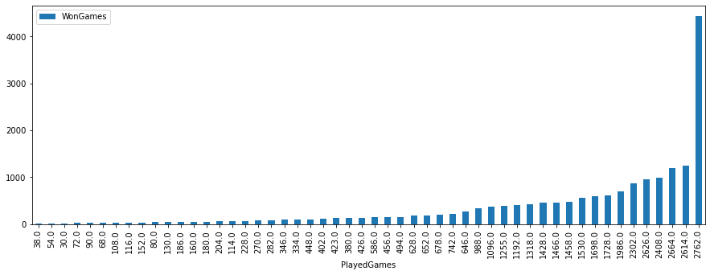

```python
# plot showing which team played more games v/s won games
bb.groupby(by=['PlayedGames'])['WonGames'].sum().reset_index().sort_values(['WonGames']).plot(x='PlayedGames',y='WonGames',kind='bar',figsize=(15,5));
```

from this plot it is found that teams which played more number of games won more number of games.

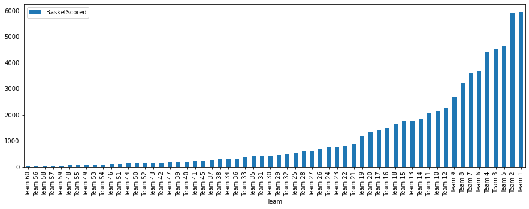

```python
# plot showing team with highest goals
bb.groupby(by=['Team'])['BasketScored'].sum().reset_index().sort_values(['BasketScored']).plot(x='Team',y='BasketScored',kind='bar',figsize=(15,5));
```

Team 1 has put more number of goals.

```python
# calculating win percenatage and lost percentage in the new dataframe (creating seperate column)
bb1['win_per%'] = round((bb1['WonGames'] / bb1['PlayedGames']) * 100,2)
bb1['lost_per%'] = round((bb['LostGames'] / bb1['PlayedGames']) * 100,2)
bb1.head()
```

|  | Team | TeamLaunch | PlayedGames | BasketScored | WonGames | TournamentChampion | win_per% | lost_per% |
| --- | --- | --- | --- | --- | --- | --- | --- | --- |
| 0 | Team 1 | 1929.0 | 2762.0 | 5947.0 | 1647.0 | 33.0 | 59.63 | 20.38 |
| 1 | Team 2 | 1929.0 | 2762.0 | 5900.0 | 1581.0 | 25.0 | 57.24 | 22.01 |
| 2 | Team 3 | 1929.0 | 2614.0 | 4534.0 | 1241.0 | 10.0 | 47.48 | 29.65 |
| 3 | Team 4 | 1931.0 | 2664.0 | 4398.0 | 1187.0 | 6.0 | 44.56 | 32.32 |
| 4 | Team 5 | 1929.0 | 2762.0 | 4631.0 | 1209.0 | 8.0 | 43.77 | 33.31 |

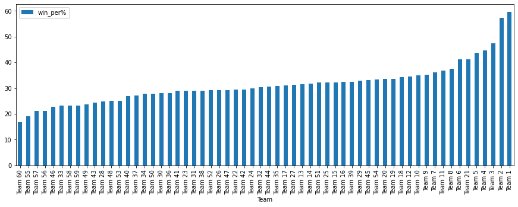

```python
# plot showing which team  v/s winning percentage
bb1.groupby(by=['Team'])['win_per%'].sum().reset_index().sort_values(['win_per%']).plot(x='Team',y='win_per%',kind='bar',figsize=(15,5));
```

rom the above observation it is found that winning percentage is more for Team 1 (winning percentage is calculated by considering winning/played games) Also, we can conclude that Team 1 is the best performing team in terms of winning games, winning tournament championship.

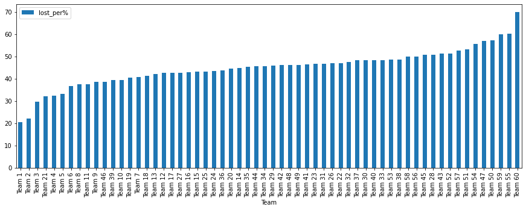

```python
# plot showing which team  v/s lost percentage
bb1.groupby(by=['Team'])['lost_per%'].sum().reset_index().sort_values(['lost_per%']).plot(x='Team',y='lost_per%',kind='bar',figsize=(15,5));
```

```python
bb.head()
```

|  | Team | Tournament | Score | PlayedGames | WonGames | DrawnGames | LostGames | BasketScored | BasketGiven | TournamentChampion | Runner-up | TeamLaunch | HighestPositionHeld |
| --- | --- | --- | --- | --- | --- | --- | --- | --- | --- | --- | --- | --- | --- |
| 0 | Team 1 | 86 | 4385 | 2762.0 | 1647.0 | 552.0 | 563.0 | 5947.0 | 3140.0 | 33.0 | 23.0 | 1929.0 | 1 |
| 1 | Team 2 | 86 | 4262 | 2762.0 | 1581.0 | 573.0 | 608.0 | 5900.0 | 3114.0 | 25.0 | 25.0 | 1929.0 | 1 |
| 2 | Team 3 | 80 | 3442 | 2614.0 | 1241.0 | 598.0 | 775.0 | 4534.0 | 3309.0 | 10.0 | 8.0 | 1929.0 | 1 |
| 3 | Team 4 | 82 | 3386 | 2664.0 | 1187.0 | 616.0 | 861.0 | 4398.0 | 3469.0 | 6.0 | 6.0 | 1931.0 | 1 |
| 4 | Team 5 | 86 | 3368 | 2762.0 | 1209.0 | 633.0 | 920.0 | 4631.0 | 3700.0 | 8.0 | 7.0 | 1929.0 | 1 |

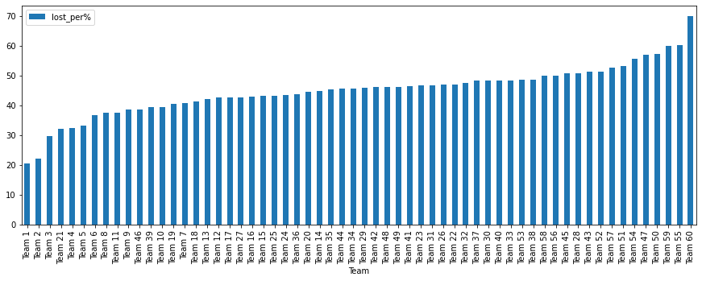

```python
bb1.groupby(by=['Team'])['lost_per%'].sum().reset_index().sort_values(['lost_per%']).plot(x='Team',y='lost_per%',kind='bar',figsize=(15,5));
```

From the above observation it is found that loosing percentage is more for Team 60 (loosing percentage is calculated by considering no. lost games/played games) Also, we can conclude that Team 60 is on weeker side interms of loosing games,scoring goals and winning tournament championship.

```python
# corelation matrix to analyse the relatioship between variables.
bb.corr()
```

|  | Tournament | Score | PlayedGames | WonGames | DrawnGames | LostGames | BasketScored | BasketGiven | TournamentChampion | Runner-up | TeamLaunch | HighestPositionHeld |
| --- | --- | --- | --- | --- | --- | --- | --- | --- | --- | --- | --- | --- |
| Tournament | 1.000000 | 0.981258 | 0.998683 | 0.971749 | 0.989295 | 0.949350 | 0.974867 | 0.987781 | 0.630689 | 0.650284 | -0.599166 | -0.708002 |
| Score | 0.981258 | 1.000000 | 0.979687 | 0.997232 | 0.958090 | 0.878780 | 0.996634 | 0.943801 | 0.872764 | 0.833611 | -0.538542 | -0.669215 |
| PlayedGames | 0.998683 | 0.979687 | 1.000000 | 0.967486 | 0.993972 | 0.955925 | 0.969970 | 0.990020 | 0.614738 | 0.636178 | -0.581243 | -0.711065 |
| WonGames | 0.971749 | 0.997232 | 0.967486 | 1.000000 | 0.939416 | 0.851436 | 0.999312 | 0.925745 | 0.882823 | 0.852441 | -0.540421 | -0.647819 |
| DrawnGames | 0.989295 | 0.958090 | 0.993972 | 0.939416 | 1.000000 | 0.972786 | 0.942234 | 0.992479 | 0.308734 | 0.474282 | -0.570175 | -0.720248 |
| LostGames | 0.949350 | 0.878780 | 0.955925 | 0.851436 | 0.972786 | 1.000000 | 0.857843 | 0.985041 | -0.538801 | -0.019934 | -0.591571 | -0.726172 |
| BasketScored | 0.974867 | 0.996634 | 0.969970 | 0.999312 | 0.942234 | 0.857843 | 1.000000 | 0.931079 | 0.862878 | 0.841565 | -0.550150 | -0.648672 |
| BasketGiven | 0.987781 | 0.943801 | 0.990020 | 0.925745 | 0.992479 | 0.985041 | 0.931079 | 1.000000 | 0.194981 | 0.406678 | -0.608902 | -0.727323 |
| TournamentChampion | 0.630689 | 0.872764 | 0.614738 | 0.882823 | 0.308734 | -0.538801 | 0.862878 | 0.194981 | 1.000000 | 0.961435 | -0.485495 | NaN |
| Runner-up | 0.650284 | 0.833611 | 0.636178 | 0.852441 | 0.474282 | -0.019934 | 0.841565 | 0.406678 | 0.961435 | 1.000000 | -0.370153 | -0.569812 |
| TeamLaunch | -0.599166 | -0.538542 | -0.581243 | -0.540421 | -0.570175 | -0.591571 | -0.550150 | -0.608902 | -0.485495 | -0.370153 | 1.000000 | 0.599679 |
| HighestPositionHeld | -0.708002 | -0.669215 | -0.711065 | -0.647819 | -0.720248 | -0.726172 | -0.648672 | -0.727323 | NaN | -0.569812 | 0.599679 | 1.000000 |

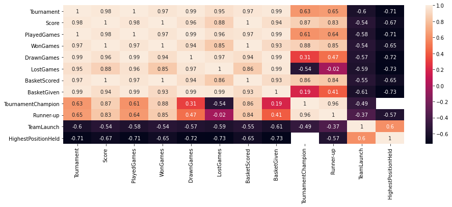

```python
fig = plt.figure(figsize = (15,5))
sns.heatmap(bb.corr(), annot=True);
```

rom the graph it is infered that 1.There is a strong co-relation between Tournament and Score that means the team which scored more has played more number of tournament. 2. The team which which scored more basket has won more games 3. The team which played more has drawn as well as lost more games. 4. The team which last more games has given more basket. 5. Basket scored is linearly proportional to the score and winning games.

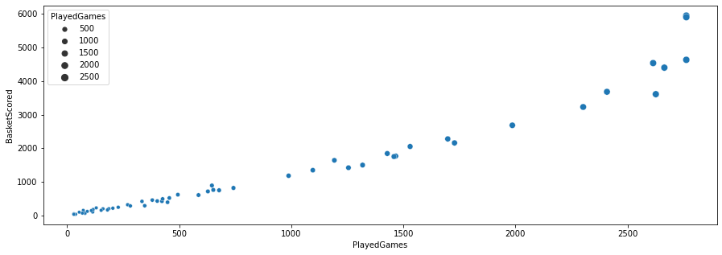

```python
figure = plt.figure(figsize=(15,5))

ax = sns.scatterplot(x=bb['PlayedGames'],y='BasketScored', data=bb, size = "PlayedGames") # scatter plot
```

From the above fraph it is learnt that there is a almost linear relationship between played games v/s basket scored.

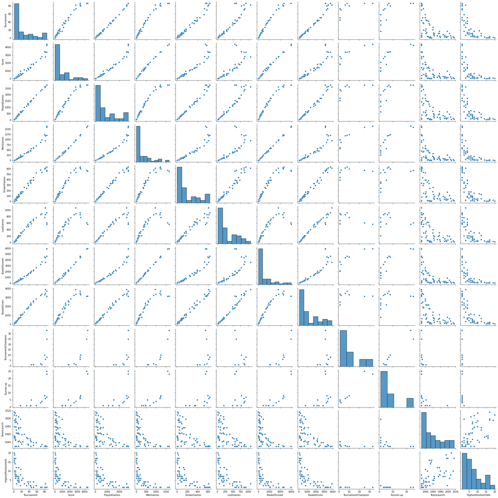

```python
plt.figure(figsize=(15,5))
sns.pairplot(bb);
```

# PART THREE - PROJECT BASED

```python
#importing libraries
import numpy as np
import pandas as pd
import matplotlib.pyplot as plt
import seaborn as sns
%matplotlib inline
```

# 1. Data Warehouse:(reading CSV file)

# Read the CSV file.

```python
df = pd.read_csv('DS - Part3 - CompanyX_EU.csv')    #reading CSV file
df.head()
```

|  | Startup | Product | Funding | Event | Result | OperatingState |
| --- | --- | --- | --- | --- | --- | --- |
| 0 | 2600Hz | 2600hz.com | NaN | Disrupt SF 2013 | Contestant | Operating |
| 1 | 3DLT | 3dlt.com | $630K | Disrupt NYC 2013 | Contestant | Closed |
| 2 | 3DPrinterOS | 3dprinteros.com | NaN | Disrupt SF 2016 | Contestant | Operating |
| 3 | 3Dprintler | 3dprintler.com | $1M | Disrupt NY 2016 | Audience choice | Operating |
| 4 | 42 Technologies | 42technologies.com | NaN | Disrupt NYC 2013 | Contestant | Operating |

# 2. Data exploration:

# Check the datatypes of each attribute

```python
df.info()                                           #checking datatype of each atributes
```

```
<class 'pandas.core.frame.DataFrame'>
RangeIndex: 662 entries, 0 to 661
Data columns (total 6 columns):
 #   Column          Non-Null Count  Dtype
---  ------          --------------  -----
 0   Startup         662 non-null    object
 1   Product         656 non-null    object
 2   Funding         448 non-null    object
 3   Event           662 non-null    object
 4   Result          662 non-null    object
 5   OperatingState  662 non-null    object
dtypes: object(6)
memory usage: 31.2+ KB
```

```python
df.shape                                    #the given dataset has 662 rows and 6 columns
```

```
(662, 6)
```

# Check for null values in the attributes

```python
df.isnull().sum()
```

```
Startup             0
Product             6
Funding           214
Event               0
Result              0
OperatingState      0
dtype: int64
```

# 3. Data preprocessing & visualisation:

# Drop the null values.

```python
df.dropna(inplace=True)                #drop the null values:
df.isnull().sum()                      #checking whether null values are dropped and found no more null values
```

```
Startup           0
Product           0
Funding           0
Event             0
Result            0
OperatingState    0
dtype: int64
```

# Convert the ‘Funding’ features to a numerical value

```python
df['Funding'] = df['Funding'].replace({'\$':''}, regex = True)   # remove the $ from the Funding column
df.rename(columns = {'Funding':'Funding in $'}, inplace = True)  # change the column name from 'Funding' to 'Funding in $'
df.head()
```

|  | Startup | Product | Funding in $ | Event | Result | OperatingState |
| --- | --- | --- | --- | --- | --- | --- |
| 1 | 3DLT | 3dlt.com | 630K | Disrupt NYC 2013 | Contestant | Closed |
| 3 | 3Dprintler | 3dprintler.com | 1M | Disrupt NY 2016 | Audience choice | Operating |
| 5 | 5to1 | 5to1.com | 19.3M | TC50 2009 | Contestant | Acquired |
| 6 | 8 Securities | 8securities.com | 29M | Disrupt Beijing 2011 | Finalist | Operating |
| 10 | AdhereTech | adheretech.com | 1.8M | Hardware Battlefield 2014 | Contestant | Operating |

```python
# simple program to remove 'K' and 'M' from the column and multiply with the corresponding values.
def value_to_float(x):
    if type(x) == float or type(x) == int:                  # defining a function to convert the values in 'K','M' and
                                                           # 'B' to its respective values
        return x
    if 'K' in x:
        if len(x) > 1:
            return float(x.replace('K', '')) * 1000
        return 1000.0
    if 'M' in x:
        if len(x) > 1:
            return float(x.replace('M', '')) * 1000000
        return 1000000.0
    if 'B' in x:
        return float(x.replace('B', '')) * 1000000000
    return 0.0

df['Funding in $'] = df['Funding in $'].apply(value_to_float)
df.head()
```

|  | Startup | Product | Funding in $ | Event | Result | OperatingState |
| --- | --- | --- | --- | --- | --- | --- |
| 1 | 3DLT | 3dlt.com | 630000.0 | Disrupt NYC 2013 | Contestant | Closed |
| 3 | 3Dprintler | 3dprintler.com | 1000000.0 | Disrupt NY 2016 | Audience choice | Operating |
| 5 | 5to1 | 5to1.com | 19300000.0 | TC50 2009 | Contestant | Acquired |
| 6 | 8 Securities | 8securities.com | 29000000.0 | Disrupt Beijing 2011 | Finalist | Operating |
| 10 | AdhereTech | adheretech.com | 1800000.0 | Hardware Battlefield 2014 | Contestant | Operating |

Observation : 'K','M' and 'B' values are added by replacing symbol.

```python
 #chnaging column name to 'Funding in Million($)
df.rename(columns = {'Funding in $':'Funding in Million($)'}, inplace = True)
df['Funding in Million($)'] = df['Funding in Million($)'].divide(1000000)      # dividing the entire column by 1000000
df.head()
```

|  | Startup | Product | Funding in Million($) | Event | Result | OperatingState |
| --- | --- | --- | --- | --- | --- | --- |
| 1 | 3DLT | 3dlt.com | 0.63 | Disrupt NYC 2013 | Contestant | Closed |
| 3 | 3Dprintler | 3dprintler.com | 1.00 | Disrupt NY 2016 | Audience choice | Operating |
| 5 | 5to1 | 5to1.com | 19.30 | TC50 2009 | Contestant | Acquired |
| 6 | 8 Securities | 8securities.com | 29.00 | Disrupt Beijing 2011 | Finalist | Operating |
| 10 | AdhereTech | adheretech.com | 1.80 | Hardware Battlefield 2014 | Contestant | Operating |

# Plot box plot for funds in million.

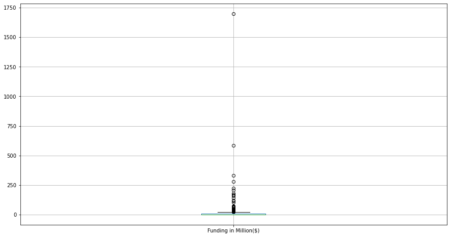

```python
df.boxplot(column='Funding in Million($)',return_type='axes',figsize=(15,8));  # boxplot for funds in million
```

# Get the lower fense from the boxplot

```python
Q1 = df['Funding in Million($)'].quantile(0.25)                   # lower fence from the boxplot
Q3 = df['Funding in Million($)'].quantile(0.75)
IQR =df['Funding in Million($)'].quantile(0.75)-df['Funding in Million($)'].quantile(0.25)
lower_fence = Q1 - 1.5*IQR
upper_fence = Q3 +1.5*IQR
print(f'''The lower fence is {lower_fence}''')
```

```
The lower fence is -12.349374999999998
```

```python
upper_fence
```

```
22.569625
```

# Check number of outliers greater than upper fence

```python
df[(df['Funding in Million($)'] > upper_fence)]    #since upper_fence is 22.5 the values above that are displayed below
```

|  | Startup | Product | Funding in Million($) | Event | Result | OperatingState |
| --- | --- | --- | --- | --- | --- | --- |
| 6 | 8 Securities | 8securities.com | 29.0 | Disrupt Beijing 2011 | Finalist | Operating |
| 31 | Anyclip | anyclip.com | 24.0 | TC50 2009 | Finalist | Operating |
| 40 | Artsy | artsy.net | 50.9 | Disrupt NYC 2010 | Contestant | Operating |
| 49 | Badgeville | badgeville.com | 40.0 | Disrupt SF 2010 | Finalist | Acquired |
| 56 | Betterment | betterment.com | 205.0 | Disrupt NYC 2010 | Finalist | Operating |
| 108 | Clickable | clickable.com | 32.5 | TC40 2007 | Finalist | Acquired |
| 113 | Cloudflare | cloudflare.com | 182.1 | Disrupt SF 2010 | Runner up | Operating |
| 128 | Credit Sesame | creditsesame.com | 35.4 | Disrupt SF 2010 | Contestant | Operating |
| 130 | CrowdFlower Inc. | crowdflower.com | 38.0 | TC50 2009 | Contestant | Operating |
| 132 | Cubic Telecom | cubictelecom.com | 37.1 | TC40 2007 | Contestant | Operating |
| 138 | DataSift | datasift.com | 72.0 | Disrupt SF 2010 | Finalist | Operating |
| 139 | DataXu | dataxu.com | 64.0 | TC50 2009 | Contestant | Operating |
| 154 | Dropbox | dropbox.com | 1700.0 | TC50 2008 | Contestant | Operating |
| 166 | Enigma | enigma.io | 34.6 | Disrupt NYC 2013 | Winner | Operating |
| 172 | EverythingMe | everything.me | 35.5 | Disrupt NYC 2011 | Contestant | Closed |
| 179 | Famo.us | famo.us | 30.1 | Disrupt SF 2012 | Contestant | Operating |
| 180 | Farmigo | farmigo.com | 26.0 | Disrupt SF 2011 | Finalist | Operating |
| 188 | Fitbit | fitbit.com | 66.0 | TC50 2008 | Finalist | Ipo |
| 191 | Flock | flock.com | 28.3 | TC40 2007 | Contestant | Acquired |
| 209 | Getaround | getaround.com | 103.0 | Disrupt NYC 2011 | Winner | Operating |
| 213 | Gild | gild.com | 25.9 | Disrupt SF 2010 | Contestant | Acquired |
| 215 | Glide | glide.me | 36.5 | Disrupt NYC 2013 | Audience choice | Operating |
| 225 | Grockit | grockit.com | 44.7 | TC50 2008 | Finalist | Acquired |
| 231 | HackerRank | hackerrank.com | 24.2 | Disrupt SF 2012 | Contestant | Operating |
| 271 | Ionic Security | ionicsecurity.com | 122.4 | Disrupt SF 2012 | Contestant | Operating |
| 276 | IZEA | izea.com | 34.9 | Disrupt NYC 2010 | Contestant | Ipo |
| 279 | Jiff | jiff.com | 67.8 | Disrupt SF 2011 | Contestant | Acquired |
| 282 | Kaltura | kaltura.com | 166.1 | TC40 2007 | Audience choice | Operating |
| 302 | Layer | layer.com | 42.1 | Disrupt SF 2013 | Winner | Operating |
| 305 | LearnVest | learnvest.com | 69.0 | TC50 2009 | Contestant | Acquired |
| 313 | LiveIntent | liveintent.com | 65.1 | Disrupt NYC 2010 | Audience choice | Operating |
| 325 | Lystable | lystable.com | 25.1 | Disrupt London 2015 | Finalist | Operating |
| 346 | Mint | mint.com | 31.8 | TC40 2007 | Winner | Acquired |
| 389 | OrderWithMe | orderwithme.com | 37.0 | Disrupt Beijing 2011 | Winner | Operating |
| 393 | Osmo | playosmo.com | 38.5 | Disrupt SF 2013 | Contestant | Operating |
| 394 | Ossia | ossia.com | 25.5 | Disrupt SF 2013 | Runner up | Operating |
| 398 | Owlet Baby Care | owletcare.com | 24.0 | Hardware Battlefield 2014 | Runner up | Operating |
| 427 | Postmates | postmates.com | 278.0 | Disrupt SF 2011 | Contestant | Operating |
| 432 | Prism Skylabs | prism.com | 24.0 | Disrupt SF 2011 | Runner up | Operating |
| 435 | PubMatic | pubmatic.com | 63.0 | TC40 2007 | Contestant | Operating |
| 460 | Roadie | roadie.com | 25.0 | Disrupt NYC 2014 | Audience choice | Operating |
| 471 | SeatGeek | seatgeek.com | 160.0 | TC50 2009 | Contestant | Operating |
| 546 | StyleSeat | styleseat.com | 40.0 | Disrupt NYC 2011 | Contestant | Operating |
| 555 | Symphony Commerce | symphonycommerce.com | 47.4 | Disrupt NYC 2011 | Contestant | Operating |
| 560 | Talkdesk | talkdesk.com | 24.5 | Disrupt NYC 2012 | Contestant | Operating |
| 581 | TouchPal | touchpal.com | 25.0 | Disrupt Beijing 2011 | Finalist | Operating |
| 593 | TrueCar | truecar.com | 332.4 | TC50 2008 | Contestant | Ipo |
| 598 | UberConference | uberconference.com | 35.0 | Disrupt NYC 2012 | Winner | Operating |
| 606 | Upwork | upwork.com | 168.8 | TC50 2009 | Audience choice | Operating |
| 615 | VideoSurf | videosurf.com | 28.0 | TC50 2008 | Contestant | Acquired |
| 625 | Voxy | voxy.com | 30.8 | Disrupt SF 2010 | Contestant | Operating |
| 643 | Xobni | yahoo.com | 41.8 | TC40 2007 | Contestant | Acquired |
| 644 | Yammer | yammer.com | 142.0 | TC50 2008 | Winner | Acquired |
| 647 | Yext | yext.com | 117.8 | TC50 2009 | Contestant | Ipo |
| 649 | YouNow | younow.com | 26.0 | Disrupt SF 2011 | Contestant | Operating |
| 650 | YourMechanic | yourmechanic.com | 28.0 | Disrupt SF 2012 | Winner | Operating |
| 654 | ZEFR | zefr.com | 62.1 | Disrupt NYC 2010 | Contestant | Operating |
| 656 | Zenefits | zenefits.com | 583.6 | Disrupt NYC 2013 | Finalist | Operating |
| 659 | Zocdoc | zocdoc.com | 223.0 | TC40 2007 | Contestant | Operating |
| 661 | Zumper | zumper.com | 31.5 | Disrupt SF 2012 | Finalist | Operating |

# Drop the values that are greater than upper fence.

```python
df_value_greater_than_upperfence = df[~(df['Funding in Million($)'] > upper_fence)]    # values above the upper_fence are dropped
df_value_greater_than_upperfence
```

|  | Startup | Product | Funding in Million($) | Event | Result | OperatingState |
| --- | --- | --- | --- | --- | --- | --- |
| 1 | 3DLT | 3dlt.com | 0.63 | Disrupt NYC 2013 | Contestant | Closed |
| 3 | 3Dprintler | 3dprintler.com | 1.00 | Disrupt NY 2016 | Audience choice | Operating |
| 5 | 5to1 | 5to1.com | 19.30 | TC50 2009 | Contestant | Acquired |
| 10 | AdhereTech | adheretech.com | 1.80 | Hardware Battlefield 2014 | Contestant | Operating |
| 11 | AdRocket | adrocket.com | 1.00 | TC50 2008 | Contestant | Closed |
| ... | ... | ... | ... | ... | ... | ... |
| 645 | Yap | yapme.com | 10.00 | TC40 2007 | Contestant | Closed |
| 646 | YayPay Inc | yaypay.com | 0.90 | Disrupt London 2015 | Contestant | Operating |
| 657 | Zivity | zivity.com | 8.00 | TC40 2007 | Contestant | Operating |
| 658 | Zmorph | zmorph3d.com | 1.00 | - | Audience choice | Operating |
| 660 | Zula | zulaapp.com | 3.40 | Disrupt SF 2013 | Audience choice | Operating |

386 rows × 6 columns

# Plot the box plot after dropping the values.

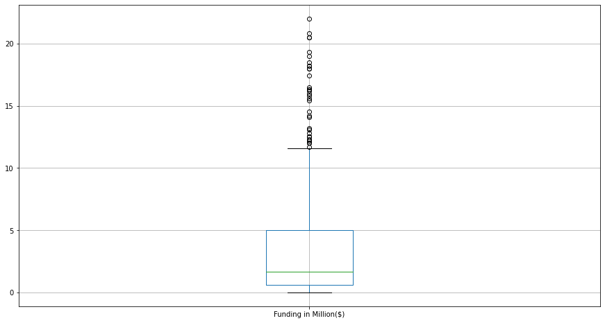

```python
df_value_greater_than_upperfence.boxplot(column='Funding in Million($)',return_type='axes',figsize=(15,8));  #box plot after dropping the values
```

# Check frequency of the Operating State features classes.

```python
df['OperatingState'].value_counts()           # tells the status of opearating status of the startups
```

```
Operating    319
Acquired      66
Closed        57
Ipo            4
Name: OperatingState, dtype: int64
```

```python
df_value_greater_than_upperfence['OperatingState'].value_counts()  # status after removing outliers above upper fence
```

```
Operating    275
Closed        56
Acquired      55
Name: OperatingState, dtype: int64
```

# Plot a distribution plot for Funds in million.

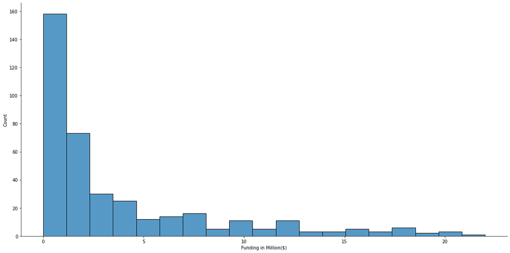

```python
#after removing outliers above upper fence
sns.displot(x=df_value_greater_than_upperfence['Funding in Million($)'],height=8,aspect=2);
```

# Plot distribution plots for companies still operating and companies that closed.

```python
df_operating = df_value_greater_than_upperfence[df_value_greater_than_upperfence["OperatingState"].isin(['Operating'])]
df_operating.head()
```

|  | Startup | Product | Funding in Million($) | Event | Result | OperatingState |
| --- | --- | --- | --- | --- | --- | --- |
| 3 | 3Dprintler | 3dprintler.com | 1.0000 | Disrupt NY 2016 | Audience choice | Operating |
| 10 | AdhereTech | adheretech.com | 1.8000 | Hardware Battlefield 2014 | Contestant | Operating |
| 13 | Agrilyst | agrilyst.com | 1.0000 | Disrupt SF 2015 | Winner | Operating |
| 14 | Aiden | aiden.ai | 0.7500 | Disrupt London 2016 | Contestant | Operating |
| 15 | AirBoxLab | foobot.io | 0.0179 | Hardware Battlefield 2014 | Contestant | Operating |

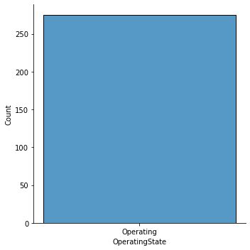

```python
#considering the value new dataframe i.e. after removing outliers above upper fence(275 companies are operating)
sns.displot(x=df_operating['OperatingState']);  #distribution plot for only companies that are operating
```

```python
df_closed = df_value_greater_than_upperfence[df_value_greater_than_upperfence["OperatingState"].isin(['Closed'])]
df_closed.head()
```

|  | Startup | Product | Funding in Million($) | Event | Result | OperatingState |
| --- | --- | --- | --- | --- | --- | --- |
| 1 | 3DLT | 3dlt.com | 0.6300 | Disrupt NYC 2013 | Contestant | Closed |
| 11 | AdRocket | adrocket.com | 1.0000 | TC50 2008 | Contestant | Closed |
| 17 | AirDroids | airdroids.com | 0.9292 | Hardware Battlefield 2014 | Contestant | Closed |
| 20 | Akoha | akoha.com | 1.9000 | TC50 2008 | Contestant | Closed |
| 34 | Appbistro | appbistro.com | 0.6000 | Disrupt NYC 2010 | Contestant | Closed |

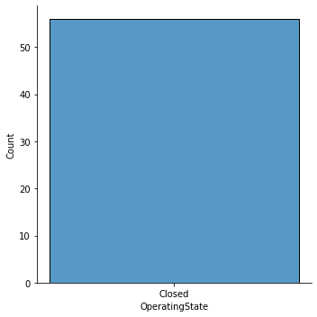

```python
sns.displot(x=df_closed['OperatingState']);  #distribution plot for companies those are closed
#considering the value new dataframe i.e. after removing outliers above upper fence(56 companies are closed)
```

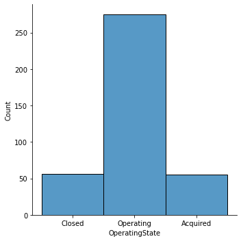

```python
#distribution plot showing 'operating state','closed' and 'acquired'
fig = plt.figure(figsize = (15,5))
sns.displot(data=df_value_greater_than_upperfence,x='OperatingState');
```

# 4. Statistical analysis:

# Is there any significant difference between Funds raised by companies that are still operating vs companies that closed down?

Write the null hypothesis and alternative hypothesis. Test for significance and conclusion

Step 1: Define null and alternative hypotheses. Null hypothesis, H0: μ1 = μ2: Funds raised by companies that are still operating and companies that closed down are equal Alternate hypothesis,H1: μ1 ≠ μ2: Funds raised by companies that are still operating and companies that closed down are not equal.

```python
df_operating.describe()       # companies that are operating
```

|  | Funding in Million($) |
| --- | --- |
| count | 275.000000 |
| mean | 3.517953 |
| std | 4.430511 |
| min | 0.005000 |
| 25% | 0.578050 |
| 50% | 1.700000 |
| 75% | 4.500000 |
| max | 22.000000 |

```python
df_closed.describe()          # companies that are closed
```

|  | Funding in Million($) |
| --- | --- |
| count | 56.000000 |
| mean | 2.682423 |
| std | 4.060193 |
| min | 0.093000 |
| 25% | 0.443750 |
| 50% | 0.927100 |
| 75% | 3.125000 |
| max | 20.800000 |

companies that are operating let n1(companies that are operating) = 275 n2(companies that are closed) =56 Mean value of the funds raised by the companies that are operating in million $, μ1 =3.517 Mean value of the funds raised by the companies that are closed in million $, μ2 =2.68Step 2: Decide the significance level Choose the 𝛼 , the level of significance according to the relative importance of the risks of committing Type I and Type II errors in the problem. let,𝛼 = 0.05 Step 3: Decide the significance level since n1 ≠ n2 μ1 ≠ μ2 standard deviation values are known, will go for 2 samples t test. Step 4: Calculate the p - value and test statistic

```python
from    scipy.stats             import  ttest_1samp,ttest_ind, wilcoxon, ttest_ind_from_stats
import  scipy.stats             as      stats
from    statsmodels.stats.power import  ttest_power
```

```python
df_operating
df_closed.head()
```

|  | Startup | Product | Funding in Million($) | Event | Result | OperatingState |
| --- | --- | --- | --- | --- | --- | --- |
| 1 | 3DLT | 3dlt.com | 0.6300 | Disrupt NYC 2013 | Contestant | Closed |
| 11 | AdRocket | adrocket.com | 1.0000 | TC50 2008 | Contestant | Closed |
| 17 | AirDroids | airdroids.com | 0.9292 | Hardware Battlefield 2014 | Contestant | Closed |
| 20 | Akoha | akoha.com | 1.9000 | TC50 2008 | Contestant | Closed |
| 34 | Appbistro | appbistro.com | 0.6000 | Disrupt NYC 2010 | Contestant | Closed |

```python
t_statistic, p_value  =  stats.ttest_ind(df_operating['Funding in Million($)'],df_closed['Funding in Million($)'])
print(f'''t statistics ={t_statistic} and p-value = {p_value}''')
```

```
t statistics =1.3039132895334589 and p-value = 0.1931747168826862
```